# 1. Downloading and preparing the data

## Downloading

```python
import sklearn
import joblib
import pandas as pd
import numpy as np
from joblib import dump
import matplotlib.pyplot as plt
from scipy import stats as st
import seaborn as sns
from sklearn.utils import shuffle
from sklearn.model_selection import train_test_split, cross_val_score
from sklearn.ensemble import RandomForestRegressor
from sklearn.tree import DecisionTreeClassifier, DecisionTreeRegressor
from sklearn.ensemble import RandomForestClassifier, RandomForestRegressor
from sklearn.linear_model import LinearRegression, LogisticRegression
from sklearn.metrics import accuracy_score, confusion_matrix, f1_score, recall_score
from sklearn.metrics import mean_squared_error, r2_score, mean_absolute_error, precision_score
from sklearn.metrics import roc_auc_score, precision_recall_curve, roc_curve
from sklearn.preprocessing import OrdinalEncoder, StandardScaler
```

## 1.1. Opening the files and looking into the data

```python
# gold_recovery_train
data_train = pd.read_csv('/datasets/gold_recovery_train.csv')
display(data_train.head())
data_train.info()
data_train.describe()
data_train['rougher.input.feed_au'].unique()
```

|  | date | final.output.concentrate_ag | final.output.concentrate_pb | final.output.concentrate_sol | final.output.concentrate_au | final.output.recovery | final.output.tail_ag | final.output.tail_pb | final.output.tail_sol | final.output.tail_au | ... | secondary_cleaner.state.floatbank4_a_air | secondary_cleaner.state.floatbank4_a_level | secondary_cleaner.state.floatbank4_b_air | secondary_cleaner.state.floatbank4_b_level | secondary_cleaner.state.floatbank5_a_air | secondary_cleaner.state.floatbank5_a_level | secondary_cleaner.state.floatbank5_b_air | secondary_cleaner.state.floatbank5_b_level | secondary_cleaner.state.floatbank6_a_air | secondary_cleaner.state.floatbank6_a_level |
| --- | --- | --- | --- | --- | --- | --- | --- | --- | --- | --- | --- | --- | --- | --- | --- | --- | --- | --- | --- | --- | --- |
| 0 | 2016-01-15 00:00:00 | 6.055403 | 9.889648 | 5.507324 | 42.192020 | 70.541216 | 10.411962 | 0.895447 | 16.904297 | 2.143149 | ... | 14.016835 | -502.488007 | 12.099931 | -504.715942 | 9.925633 | -498.310211 | 8.079666 | -500.470978 | 14.151341 | -605.841980 |
| 1 | 2016-01-15 01:00:00 | 6.029369 | 9.968944 | 5.257781 | 42.701629 | 69.266198 | 10.462676 | 0.927452 | 16.634514 | 2.224930 | ... | 13.992281 | -505.503262 | 11.950531 | -501.331529 | 10.039245 | -500.169983 | 7.984757 | -500.582168 | 13.998353 | -599.787184 |
| 2 | 2016-01-15 02:00:00 | 6.055926 | 10.213995 | 5.383759 | 42.657501 | 68.116445 | 10.507046 | 0.953716 | 16.208849 | 2.257889 | ... | 14.015015 | -502.520901 | 11.912783 | -501.133383 | 10.070913 | -500.129135 | 8.013877 | -500.517572 | 14.028663 | -601.427363 |
| 3 | 2016-01-15 03:00:00 | 6.047977 | 9.977019 | 4.858634 | 42.689819 | 68.347543 | 10.422762 | 0.883763 | 16.532835 | 2.146849 | ... | 14.036510 | -500.857308 | 11.999550 | -501.193686 | 9.970366 | -499.201640 | 7.977324 | -500.255908 | 14.005551 | -599.996129 |
| 4 | 2016-01-15 04:00:00 | 6.148599 | 10.142511 | 4.939416 | 42.774141 | 66.927016 | 10.360302 | 0.792826 | 16.525686 | 2.055292 | ... | 14.027298 | -499.838632 | 11.953070 | -501.053894 | 9.925709 | -501.686727 | 7.894242 | -500.356035 | 13.996647 | -601.496691 |

5 rows × 87 columns

```
<class 'pandas.core.frame.DataFrame'>
RangeIndex: 16860 entries, 0 to 16859
Data columns (total 87 columns):
date                                                  16860 non-null object
final.output.concentrate_ag                           16788 non-null float64
final.output.concentrate_pb                           16788 non-null float64
final.output.concentrate_sol                          16490 non-null float64
final.output.concentrate_au                           16789 non-null float64
final.output.recovery                                 15339 non-null float64
final.output.tail_ag                                  16794 non-null float64
final.output.tail_pb                                  16677 non-null float64
final.output.tail_sol                                 16715 non-null float64
final.output.tail_au                                  16794 non-null float64
primary_cleaner.input.sulfate                         15553 non-null float64
primary_cleaner.input.depressant                      15598 non-null float64
primary_cleaner.input.feed_size                       16860 non-null float64
primary_cleaner.input.xanthate                        15875 non-null float64
primary_cleaner.output.concentrate_ag                 16778 non-null float64
primary_cleaner.output.concentrate_pb                 16502 non-null float64
primary_cleaner.output.concentrate_sol                16224 non-null float64
primary_cleaner.output.concentrate_au                 16778 non-null float64
primary_cleaner.output.tail_ag                        16777 non-null float64
primary_cleaner.output.tail_pb                        16761 non-null float64
primary_cleaner.output.tail_sol                       16579 non-null float64
primary_cleaner.output.tail_au                        16777 non-null float64
primary_cleaner.state.floatbank8_a_air                16820 non-null float64
primary_cleaner.state.floatbank8_a_level              16827 non-null float64
primary_cleaner.state.floatbank8_b_air                16820 non-null float64
primary_cleaner.state.floatbank8_b_level              16833 non-null float64
primary_cleaner.state.floatbank8_c_air                16822 non-null float64
primary_cleaner.state.floatbank8_c_level              16833 non-null float64
primary_cleaner.state.floatbank8_d_air                16821 non-null float64
primary_cleaner.state.floatbank8_d_level              16833 non-null float64
rougher.calculation.sulfate_to_au_concentrate         16833 non-null float64
rougher.calculation.floatbank10_sulfate_to_au_feed    16833 non-null float64
rougher.calculation.floatbank11_sulfate_to_au_feed    16833 non-null float64
rougher.calculation.au_pb_ratio                       15618 non-null float64
rougher.input.feed_ag                                 16778 non-null float64
rougher.input.feed_pb                                 16632 non-null float64
rougher.input.feed_rate                               16347 non-null float64
```

[output cut: 37 more lines]

```
secondary_cleaner.state.floatbank3_a_level            16747 non-null float64
secondary_cleaner.state.floatbank3_b_air              16752 non-null float64
secondary_cleaner.state.floatbank3_b_level            16750 non-null float64
secondary_cleaner.state.floatbank4_a_air              16731 non-null float64
secondary_cleaner.state.floatbank4_a_level            16747 non-null float64
secondary_cleaner.state.floatbank4_b_air              16768 non-null float64
secondary_cleaner.state.floatbank4_b_level            16767 non-null float64
secondary_cleaner.state.floatbank5_a_air              16775 non-null float64
secondary_cleaner.state.floatbank5_a_level            16775 non-null float64
secondary_cleaner.state.floatbank5_b_air              16775 non-null float64
secondary_cleaner.state.floatbank5_b_level            16776 non-null float64
secondary_cleaner.state.floatbank6_a_air              16757 non-null float64
secondary_cleaner.state.floatbank6_a_level            16775 non-null float64
dtypes: float64(86), object(1)
memory usage: 11.2+ MB
```

```
array([6.48614979, 6.47858279, 6.36222199, ..., 4.52506124, 4.36278136,
       4.36549126])
```

```python
# gold_recovery_test
data_test = pd.read_csv('/datasets/gold_recovery_test.csv')
display(data_test.head())
data_test.info()
data_test.describe()
```

|  | date | primary_cleaner.input.sulfate | primary_cleaner.input.depressant | primary_cleaner.input.feed_size | primary_cleaner.input.xanthate | primary_cleaner.state.floatbank8_a_air | primary_cleaner.state.floatbank8_a_level | primary_cleaner.state.floatbank8_b_air | primary_cleaner.state.floatbank8_b_level | primary_cleaner.state.floatbank8_c_air | ... | secondary_cleaner.state.floatbank4_a_air | secondary_cleaner.state.floatbank4_a_level | secondary_cleaner.state.floatbank4_b_air | secondary_cleaner.state.floatbank4_b_level | secondary_cleaner.state.floatbank5_a_air | secondary_cleaner.state.floatbank5_a_level | secondary_cleaner.state.floatbank5_b_air | secondary_cleaner.state.floatbank5_b_level | secondary_cleaner.state.floatbank6_a_air | secondary_cleaner.state.floatbank6_a_level |
| --- | --- | --- | --- | --- | --- | --- | --- | --- | --- | --- | --- | --- | --- | --- | --- | --- | --- | --- | --- | --- | --- |
| 0 | 2016-09-01 00:59:59 | 210.800909 | 14.993118 | 8.080000 | 1.005021 | 1398.981301 | -500.225577 | 1399.144926 | -499.919735 | 1400.102998 | ... | 12.023554 | -497.795834 | 8.016656 | -501.289139 | 7.946562 | -432.317850 | 4.872511 | -500.037437 | 26.705889 | -499.709414 |
| 1 | 2016-09-01 01:59:59 | 215.392455 | 14.987471 | 8.080000 | 0.990469 | 1398.777912 | -500.057435 | 1398.055362 | -499.778182 | 1396.151033 | ... | 12.058140 | -498.695773 | 8.130979 | -499.634209 | 7.958270 | -525.839648 | 4.878850 | -500.162375 | 25.019940 | -499.819438 |
| 2 | 2016-09-01 02:59:59 | 215.259946 | 12.884934 | 7.786667 | 0.996043 | 1398.493666 | -500.868360 | 1398.860436 | -499.764529 | 1398.075709 | ... | 11.962366 | -498.767484 | 8.096893 | -500.827423 | 8.071056 | -500.801673 | 4.905125 | -499.828510 | 24.994862 | -500.622559 |
| 3 | 2016-09-01 03:59:59 | 215.336236 | 12.006805 | 7.640000 | 0.863514 | 1399.618111 | -498.863574 | 1397.440120 | -499.211024 | 1400.129303 | ... | 12.033091 | -498.350935 | 8.074946 | -499.474407 | 7.897085 | -500.868509 | 4.931400 | -499.963623 | 24.948919 | -498.709987 |
| 4 | 2016-09-01 04:59:59 | 199.099327 | 10.682530 | 7.530000 | 0.805575 | 1401.268123 | -500.808305 | 1398.128818 | -499.504543 | 1402.172226 | ... | 12.025367 | -500.786497 | 8.054678 | -500.397500 | 8.107890 | -509.526725 | 4.957674 | -500.360026 | 25.003331 | -500.856333 |

5 rows × 53 columns

```
<class 'pandas.core.frame.DataFrame'>
RangeIndex: 5856 entries, 0 to 5855
Data columns (total 53 columns):
date                                          5856 non-null object
primary_cleaner.input.sulfate                 5554 non-null float64
primary_cleaner.input.depressant              5572 non-null float64
primary_cleaner.input.feed_size               5856 non-null float64
primary_cleaner.input.xanthate                5690 non-null float64
primary_cleaner.state.floatbank8_a_air        5840 non-null float64
primary_cleaner.state.floatbank8_a_level      5840 non-null float64
primary_cleaner.state.floatbank8_b_air        5840 non-null float64
primary_cleaner.state.floatbank8_b_level      5840 non-null float64
primary_cleaner.state.floatbank8_c_air        5840 non-null float64
primary_cleaner.state.floatbank8_c_level      5840 non-null float64
primary_cleaner.state.floatbank8_d_air        5840 non-null float64
primary_cleaner.state.floatbank8_d_level      5840 non-null float64
rougher.input.feed_ag                         5840 non-null float64
rougher.input.feed_pb                         5840 non-null float64
rougher.input.feed_rate                       5816 non-null float64
rougher.input.feed_size                       5834 non-null float64
rougher.input.feed_sol                        5789 non-null float64
rougher.input.feed_au                         5840 non-null float64
rougher.input.floatbank10_sulfate             5599 non-null float64
rougher.input.floatbank10_xanthate            5733 non-null float64
rougher.input.floatbank11_sulfate             5801 non-null float64
rougher.input.floatbank11_xanthate            5503 non-null float64
rougher.state.floatbank10_a_air               5839 non-null float64
rougher.state.floatbank10_a_level             5840 non-null float64
rougher.state.floatbank10_b_air               5839 non-null float64
rougher.state.floatbank10_b_level             5840 non-null float64
rougher.state.floatbank10_c_air               5839 non-null float64
rougher.state.floatbank10_c_level             5840 non-null float64
rougher.state.floatbank10_d_air               5839 non-null float64
rougher.state.floatbank10_d_level             5840 non-null float64
rougher.state.floatbank10_e_air               5839 non-null float64
rougher.state.floatbank10_e_level             5840 non-null float64
rougher.state.floatbank10_f_air               5839 non-null float64
rougher.state.floatbank10_f_level             5840 non-null float64
secondary_cleaner.state.floatbank2_a_air      5836 non-null float64
secondary_cleaner.state.floatbank2_a_level    5840 non-null float64
secondary_cleaner.state.floatbank2_b_air      5833 non-null float64
secondary_cleaner.state.floatbank2_b_level    5840 non-null float64
secondary_cleaner.state.floatbank3_a_air      5822 non-null float64
secondary_cleaner.state.floatbank3_a_level    5840 non-null float64
secondary_cleaner.state.floatbank3_b_air      5840 non-null float64
secondary_cleaner.state.floatbank3_b_level    5840 non-null float64
secondary_cleaner.state.floatbank4_a_air      5840 non-null float64
secondary_cleaner.state.floatbank4_a_level    5840 non-null float64
secondary_cleaner.state.floatbank4_b_air      5840 non-null float64
secondary_cleaner.state.floatbank4_b_level    5840 non-null float64
secondary_cleaner.state.floatbank5_a_air      5840 non-null float64
secondary_cleaner.state.floatbank5_a_level    5840 non-null float64
secondary_cleaner.state.floatbank5_b_air      5840 non-null float64
secondary_cleaner.state.floatbank5_b_level    5840 non-null float64
secondary_cleaner.state.floatbank6_a_air      5840 non-null float64
secondary_cleaner.state.floatbank6_a_level    5840 non-null float64
dtypes: float64(52), object(1)
memory usage: 2.4+ MB
```

|  | primary_cleaner.input.sulfate | primary_cleaner.input.depressant | primary_cleaner.input.feed_size | primary_cleaner.input.xanthate | primary_cleaner.state.floatbank8_a_air | primary_cleaner.state.floatbank8_a_level | primary_cleaner.state.floatbank8_b_air | primary_cleaner.state.floatbank8_b_level | primary_cleaner.state.floatbank8_c_air | primary_cleaner.state.floatbank8_c_level | ... | secondary_cleaner.state.floatbank4_a_air | secondary_cleaner.state.floatbank4_a_level | secondary_cleaner.state.floatbank4_b_air | secondary_cleaner.state.floatbank4_b_level | secondary_cleaner.state.floatbank5_a_air | secondary_cleaner.state.floatbank5_a_level | secondary_cleaner.state.floatbank5_b_air | secondary_cleaner.state.floatbank5_b_level | secondary_cleaner.state.floatbank6_a_air | secondary_cleaner.state.floatbank6_a_level |
| --- | --- | --- | --- | --- | --- | --- | --- | --- | --- | --- | --- | --- | --- | --- | --- | --- | --- | --- | --- | --- | --- |
| count | 5554.000000 | 5572.000000 | 5856.000000 | 5690.000000 | 5840.000000 | 5840.000000 | 5840.000000 | 5840.000000 | 5840.000000 | 5840.000000 | ... | 5840.000000 | 5840.000000 | 5840.000000 | 5840.000000 | 5840.000000 | 5840.000000 | 5840.000000 | 5840.000000 | 5840.000000 | 5840.000000 |
| mean | 170.515243 | 8.482873 | 7.264651 | 1.321420 | 1481.990241 | -509.057796 | 1486.908670 | -511.743956 | 1468.495216 | -509.741212 | ... | 15.636031 | -516.266074 | 13.145702 | -476.338907 | 12.308967 | -512.208126 | 9.470986 | -505.017827 | 16.678722 | -512.351694 |
| std | 49.608602 | 3.353105 | 0.611526 | 0.693246 | 310.453166 | 61.339256 | 313.224286 | 67.139074 | 309.980748 | 62.671873 | ... | 4.660835 | 62.756748 | 4.304086 | 105.549424 | 3.762827 | 58.864651 | 3.312471 | 68.785898 | 5.404514 | 69.919839 |
| min | 0.000103 | 0.000031 | 5.650000 | 0.000003 | 0.000000 | -799.773788 | 0.000000 | -800.029078 | 0.000000 | -799.995127 | ... | 0.000000 | -799.798523 | 0.000000 | -800.836914 | -0.223393 | -799.661076 | 0.528083 | -800.220337 | -0.079426 | -809.859706 |
| 25% | 143.340022 | 6.411500 | 6.885625 | 0.888769 | 1497.190681 | -500.455211 | 1497.150234 | -500.936639 | 1437.050321 | -501.300441 | ... | 12.057838 | -501.054741 | 11.880119 | -500.419113 | 10.123459 | -500.879383 | 7.991208 | -500.223089 | 13.012422 | -500.833821 |
| 50% | 176.103893 | 8.023252 | 7.259333 | 1.183362 | 1554.659783 | -499.997402 | 1553.268084 | -500.066588 | 1546.160672 | -500.079537 | ... | 17.001867 | -500.160145 | 14.952102 | -499.644328 | 12.062877 | -500.047621 | 9.980774 | -500.001338 | 16.007242 | -500.041085 |
| 75% | 207.240761 | 10.017725 | 7.650000 | 1.763797 | 1601.681656 | -499.575313 | 1601.784707 | -499.323361 | 1600.785573 | -499.009545 | ... | 18.030985 | -499.441529 | 15.940011 | -401.523664 | 15.017881 | -499.297033 | 11.992176 | -499.722835 | 21.009076 | -499.395621 |
| max | 274.409626 | 40.024582 | 15.500000 | 5.433169 | 2212.432090 | -57.195404 | 1975.147923 | -142.527229 | 1715.053773 | -150.937035 | ... | 30.051797 | -401.565212 | 31.269706 | -6.506986 | 25.258848 | -244.483566 | 14.090194 | -126.463446 | 26.705889 | -29.093593 |

8 rows × 52 columns

```python
# gold_recovery_full
data_full = pd.read_csv('/datasets/gold_recovery_full.csv')
display(data_full.head())
data_full.info()
data_full.describe()
```

|  | date | final.output.concentrate_ag | final.output.concentrate_pb | final.output.concentrate_sol | final.output.concentrate_au | final.output.recovery | final.output.tail_ag | final.output.tail_pb | final.output.tail_sol | final.output.tail_au | ... | secondary_cleaner.state.floatbank4_a_air | secondary_cleaner.state.floatbank4_a_level | secondary_cleaner.state.floatbank4_b_air | secondary_cleaner.state.floatbank4_b_level | secondary_cleaner.state.floatbank5_a_air | secondary_cleaner.state.floatbank5_a_level | secondary_cleaner.state.floatbank5_b_air | secondary_cleaner.state.floatbank5_b_level | secondary_cleaner.state.floatbank6_a_air | secondary_cleaner.state.floatbank6_a_level |
| --- | --- | --- | --- | --- | --- | --- | --- | --- | --- | --- | --- | --- | --- | --- | --- | --- | --- | --- | --- | --- | --- |
| 0 | 2016-01-15 00:00:00 | 6.055403 | 9.889648 | 5.507324 | 42.192020 | 70.541216 | 10.411962 | 0.895447 | 16.904297 | 2.143149 | ... | 14.016835 | -502.488007 | 12.099931 | -504.715942 | 9.925633 | -498.310211 | 8.079666 | -500.470978 | 14.151341 | -605.841980 |
| 1 | 2016-01-15 01:00:00 | 6.029369 | 9.968944 | 5.257781 | 42.701629 | 69.266198 | 10.462676 | 0.927452 | 16.634514 | 2.224930 | ... | 13.992281 | -505.503262 | 11.950531 | -501.331529 | 10.039245 | -500.169983 | 7.984757 | -500.582168 | 13.998353 | -599.787184 |
| 2 | 2016-01-15 02:00:00 | 6.055926 | 10.213995 | 5.383759 | 42.657501 | 68.116445 | 10.507046 | 0.953716 | 16.208849 | 2.257889 | ... | 14.015015 | -502.520901 | 11.912783 | -501.133383 | 10.070913 | -500.129135 | 8.013877 | -500.517572 | 14.028663 | -601.427363 |
| 3 | 2016-01-15 03:00:00 | 6.047977 | 9.977019 | 4.858634 | 42.689819 | 68.347543 | 10.422762 | 0.883763 | 16.532835 | 2.146849 | ... | 14.036510 | -500.857308 | 11.999550 | -501.193686 | 9.970366 | -499.201640 | 7.977324 | -500.255908 | 14.005551 | -599.996129 |
| 4 | 2016-01-15 04:00:00 | 6.148599 | 10.142511 | 4.939416 | 42.774141 | 66.927016 | 10.360302 | 0.792826 | 16.525686 | 2.055292 | ... | 14.027298 | -499.838632 | 11.953070 | -501.053894 | 9.925709 | -501.686727 | 7.894242 | -500.356035 | 13.996647 | -601.496691 |

5 rows × 87 columns

```
<class 'pandas.core.frame.DataFrame'>
RangeIndex: 22716 entries, 0 to 22715
Data columns (total 87 columns):
date                                                  22716 non-null object
final.output.concentrate_ag                           22627 non-null float64
final.output.concentrate_pb                           22629 non-null float64
final.output.concentrate_sol                          22331 non-null float64
final.output.concentrate_au                           22630 non-null float64
final.output.recovery                                 20753 non-null float64
final.output.tail_ag                                  22633 non-null float64
final.output.tail_pb                                  22516 non-null float64
final.output.tail_sol                                 22445 non-null float64
final.output.tail_au                                  22635 non-null float64
primary_cleaner.input.sulfate                         21107 non-null float64
primary_cleaner.input.depressant                      21170 non-null float64
primary_cleaner.input.feed_size                       22716 non-null float64
primary_cleaner.input.xanthate                        21565 non-null float64
primary_cleaner.output.concentrate_ag                 22618 non-null float64
primary_cleaner.output.concentrate_pb                 22268 non-null float64
primary_cleaner.output.concentrate_sol                21918 non-null float64
primary_cleaner.output.concentrate_au                 22618 non-null float64
primary_cleaner.output.tail_ag                        22614 non-null float64
primary_cleaner.output.tail_pb                        22594 non-null float64
primary_cleaner.output.tail_sol                       22365 non-null float64
primary_cleaner.output.tail_au                        22617 non-null float64
primary_cleaner.state.floatbank8_a_air                22660 non-null float64
primary_cleaner.state.floatbank8_a_level              22667 non-null float64
primary_cleaner.state.floatbank8_b_air                22660 non-null float64
primary_cleaner.state.floatbank8_b_level              22673 non-null float64
primary_cleaner.state.floatbank8_c_air                22662 non-null float64
primary_cleaner.state.floatbank8_c_level              22673 non-null float64
primary_cleaner.state.floatbank8_d_air                22661 non-null float64
primary_cleaner.state.floatbank8_d_level              22673 non-null float64
rougher.calculation.sulfate_to_au_concentrate         22672 non-null float64
rougher.calculation.floatbank10_sulfate_to_au_feed    22672 non-null float64
rougher.calculation.floatbank11_sulfate_to_au_feed    22672 non-null float64
rougher.calculation.au_pb_ratio                       21089 non-null float64
rougher.input.feed_ag                                 22618 non-null float64
rougher.input.feed_pb                                 22472 non-null float64
rougher.input.feed_rate                               22163 non-null float64
```

[output cut: 37 more lines]

```
secondary_cleaner.state.floatbank3_a_level            22587 non-null float64
secondary_cleaner.state.floatbank3_b_air              22592 non-null float64
secondary_cleaner.state.floatbank3_b_level            22590 non-null float64
secondary_cleaner.state.floatbank4_a_air              22571 non-null float64
secondary_cleaner.state.floatbank4_a_level            22587 non-null float64
secondary_cleaner.state.floatbank4_b_air              22608 non-null float64
secondary_cleaner.state.floatbank4_b_level            22607 non-null float64
secondary_cleaner.state.floatbank5_a_air              22615 non-null float64
secondary_cleaner.state.floatbank5_a_level            22615 non-null float64
secondary_cleaner.state.floatbank5_b_air              22615 non-null float64
secondary_cleaner.state.floatbank5_b_level            22616 non-null float64
secondary_cleaner.state.floatbank6_a_air              22597 non-null float64
secondary_cleaner.state.floatbank6_a_level            22615 non-null float64
dtypes: float64(86), object(1)
memory usage: 15.1+ MB
```

|  | final.output.concentrate_ag | final.output.concentrate_pb | final.output.concentrate_sol | final.output.concentrate_au | final.output.recovery | final.output.tail_ag | final.output.tail_pb | final.output.tail_sol | final.output.tail_au | primary_cleaner.input.sulfate | ... | secondary_cleaner.state.floatbank4_a_air | secondary_cleaner.state.floatbank4_a_level | secondary_cleaner.state.floatbank4_b_air | secondary_cleaner.state.floatbank4_b_level | secondary_cleaner.state.floatbank5_a_air | secondary_cleaner.state.floatbank5_a_level | secondary_cleaner.state.floatbank5_b_air | secondary_cleaner.state.floatbank5_b_level | secondary_cleaner.state.floatbank6_a_air | secondary_cleaner.state.floatbank6_a_level |
| --- | --- | --- | --- | --- | --- | --- | --- | --- | --- | --- | --- | --- | --- | --- | --- | --- | --- | --- | --- | --- | --- |
| count | 22627.000000 | 22629.000000 | 22331.000000 | 22630.000000 | 20753.000000 | 22633.000000 | 22516.000000 | 22445.000000 | 22635.000000 | 21107.000000 | ... | 22571.000000 | 22587.000000 | 22608.000000 | 22607.000000 | 22615.000000 | 22615.000000 | 22615.000000 | 22616.000000 | 22597.000000 | 22615.000000 |
| mean | 4.781559 | 9.095308 | 8.640317 | 40.001172 | 67.447488 | 8.923690 | 2.488252 | 9.523632 | 2.827459 | 140.277672 | ... | 18.205125 | -499.878977 | 14.356474 | -476.532613 | 14.883276 | -503.323288 | 11.626743 | -500.521502 | 17.976810 | -519.361465 |
| std | 2.030128 | 3.230797 | 3.785035 | 13.398062 | 11.616034 | 3.517917 | 1.189407 | 4.079739 | 1.262834 | 49.919004 | ... | 6.560700 | 80.273964 | 5.655791 | 93.822791 | 6.372811 | 72.925589 | 5.757449 | 78.956292 | 6.636203 | 75.477151 |
| min | 0.000000 | 0.000000 | 0.000000 | 0.000000 | 0.000000 | 0.000000 | 0.000000 | 0.000000 | 0.000000 | 0.000003 | ... | 0.000000 | -799.920713 | 0.000000 | -800.836914 | -0.423260 | -799.741097 | 0.427084 | -800.258209 | -0.079426 | -810.473526 |
| 25% | 4.018525 | 8.750171 | 7.116799 | 42.383721 | 63.282393 | 7.684016 | 1.805376 | 8.143576 | 2.303108 | 110.177081 | ... | 14.095940 | -500.896232 | 10.882675 | -500.309169 | 10.941299 | -500.628697 | 8.037533 | -500.167897 | 13.968418 | -500.981671 |
| 50% | 4.953729 | 9.914519 | 8.908792 | 44.653436 | 68.322258 | 9.484369 | 2.653001 | 10.212998 | 2.913794 | 141.330501 | ... | 18.007326 | -499.917108 | 14.947646 | -499.612292 | 14.859117 | -499.865158 | 10.989756 | -499.951980 | 18.004215 | -500.095463 |
| 75% | 5.862593 | 10.929839 | 10.705824 | 46.111999 | 72.950836 | 11.084557 | 3.287790 | 11.860824 | 3.555077 | 174.049914 | ... | 22.998194 | -498.361545 | 17.977502 | -400.224147 | 18.014914 | -498.489381 | 14.001193 | -499.492354 | 23.009704 | -499.526388 |
| max | 16.001945 | 17.031899 | 19.615720 | 53.611374 | 100.000000 | 19.552149 | 6.086532 | 22.861749 | 9.789625 | 274.409626 | ... | 60.000000 | -127.692333 | 31.269706 | -6.506986 | 63.116298 | -244.483566 | 39.846228 | -120.190931 | 54.876806 | -29.093593 |

8 rows × 86 columns

```python
data_train['date']= pd.to_datetime(data_train['date'], format='%Y-%m-%dT%H:%M:%S')
data_test['date']= pd.to_datetime(data_test['date'], format='%Y-%m-%dT%H:%M:%S')
data_full['date']= pd.to_datetime(data_full['date'], format='%Y-%m-%dT%H:%M:%S')
```

## Filling nan values

```python
# filling nan values
data_train = data_train.fillna(method='ffill')
display(data_train.head())
data_train.info()
data_train.describe()
```

|  | date | final.output.concentrate_ag | final.output.concentrate_pb | final.output.concentrate_sol | final.output.concentrate_au | final.output.recovery | final.output.tail_ag | final.output.tail_pb | final.output.tail_sol | final.output.tail_au | ... | secondary_cleaner.state.floatbank4_a_air | secondary_cleaner.state.floatbank4_a_level | secondary_cleaner.state.floatbank4_b_air | secondary_cleaner.state.floatbank4_b_level | secondary_cleaner.state.floatbank5_a_air | secondary_cleaner.state.floatbank5_a_level | secondary_cleaner.state.floatbank5_b_air | secondary_cleaner.state.floatbank5_b_level | secondary_cleaner.state.floatbank6_a_air | secondary_cleaner.state.floatbank6_a_level |
| --- | --- | --- | --- | --- | --- | --- | --- | --- | --- | --- | --- | --- | --- | --- | --- | --- | --- | --- | --- | --- | --- |
| 0 | 2016-01-15 00:00:00 | 6.055403 | 9.889648 | 5.507324 | 42.192020 | 70.541216 | 10.411962 | 0.895447 | 16.904297 | 2.143149 | ... | 14.016835 | -502.488007 | 12.099931 | -504.715942 | 9.925633 | -498.310211 | 8.079666 | -500.470978 | 14.151341 | -605.841980 |
| 1 | 2016-01-15 01:00:00 | 6.029369 | 9.968944 | 5.257781 | 42.701629 | 69.266198 | 10.462676 | 0.927452 | 16.634514 | 2.224930 | ... | 13.992281 | -505.503262 | 11.950531 | -501.331529 | 10.039245 | -500.169983 | 7.984757 | -500.582168 | 13.998353 | -599.787184 |
| 2 | 2016-01-15 02:00:00 | 6.055926 | 10.213995 | 5.383759 | 42.657501 | 68.116445 | 10.507046 | 0.953716 | 16.208849 | 2.257889 | ... | 14.015015 | -502.520901 | 11.912783 | -501.133383 | 10.070913 | -500.129135 | 8.013877 | -500.517572 | 14.028663 | -601.427363 |
| 3 | 2016-01-15 03:00:00 | 6.047977 | 9.977019 | 4.858634 | 42.689819 | 68.347543 | 10.422762 | 0.883763 | 16.532835 | 2.146849 | ... | 14.036510 | -500.857308 | 11.999550 | -501.193686 | 9.970366 | -499.201640 | 7.977324 | -500.255908 | 14.005551 | -599.996129 |
| 4 | 2016-01-15 04:00:00 | 6.148599 | 10.142511 | 4.939416 | 42.774141 | 66.927016 | 10.360302 | 0.792826 | 16.525686 | 2.055292 | ... | 14.027298 | -499.838632 | 11.953070 | -501.053894 | 9.925709 | -501.686727 | 7.894242 | -500.356035 | 13.996647 | -601.496691 |

5 rows × 87 columns

```
<class 'pandas.core.frame.DataFrame'>
RangeIndex: 16860 entries, 0 to 16859
Data columns (total 87 columns):
date                                                  16860 non-null datetime64[ns]
final.output.concentrate_ag                           16860 non-null float64
final.output.concentrate_pb                           16860 non-null float64
final.output.concentrate_sol                          16860 non-null float64
final.output.concentrate_au                           16860 non-null float64
final.output.recovery                                 16860 non-null float64
final.output.tail_ag                                  16860 non-null float64
final.output.tail_pb                                  16860 non-null float64
final.output.tail_sol                                 16860 non-null float64
final.output.tail_au                                  16860 non-null float64
primary_cleaner.input.sulfate                         16860 non-null float64
primary_cleaner.input.depressant                      16860 non-null float64
primary_cleaner.input.feed_size                       16860 non-null float64
primary_cleaner.input.xanthate                        16860 non-null float64
primary_cleaner.output.concentrate_ag                 16860 non-null float64
primary_cleaner.output.concentrate_pb                 16860 non-null float64
primary_cleaner.output.concentrate_sol                16860 non-null float64
primary_cleaner.output.concentrate_au                 16860 non-null float64
primary_cleaner.output.tail_ag                        16860 non-null float64
primary_cleaner.output.tail_pb                        16860 non-null float64
primary_cleaner.output.tail_sol                       16860 non-null float64
primary_cleaner.output.tail_au                        16860 non-null float64
primary_cleaner.state.floatbank8_a_air                16860 non-null float64
primary_cleaner.state.floatbank8_a_level              16860 non-null float64
primary_cleaner.state.floatbank8_b_air                16860 non-null float64
primary_cleaner.state.floatbank8_b_level              16860 non-null float64
primary_cleaner.state.floatbank8_c_air                16860 non-null float64
primary_cleaner.state.floatbank8_c_level              16860 non-null float64
primary_cleaner.state.floatbank8_d_air                16860 non-null float64
primary_cleaner.state.floatbank8_d_level              16860 non-null float64
rougher.calculation.sulfate_to_au_concentrate         16860 non-null float64
rougher.calculation.floatbank10_sulfate_to_au_feed    16860 non-null float64
rougher.calculation.floatbank11_sulfate_to_au_feed    16860 non-null float64
rougher.calculation.au_pb_ratio                       16860 non-null float64
rougher.input.feed_ag                                 16860 non-null float64
rougher.input.feed_pb                                 16860 non-null float64
rougher.input.feed_rate                               16860 non-null float64
```

[output cut: 37 more lines]

```
secondary_cleaner.state.floatbank3_a_level            16860 non-null float64
secondary_cleaner.state.floatbank3_b_air              16860 non-null float64
secondary_cleaner.state.floatbank3_b_level            16860 non-null float64
secondary_cleaner.state.floatbank4_a_air              16860 non-null float64
secondary_cleaner.state.floatbank4_a_level            16860 non-null float64
secondary_cleaner.state.floatbank4_b_air              16860 non-null float64
secondary_cleaner.state.floatbank4_b_level            16860 non-null float64
secondary_cleaner.state.floatbank5_a_air              16860 non-null float64
secondary_cleaner.state.floatbank5_a_level            16860 non-null float64
secondary_cleaner.state.floatbank5_b_air              16860 non-null float64
secondary_cleaner.state.floatbank5_b_level            16860 non-null float64
secondary_cleaner.state.floatbank6_a_air              16860 non-null float64
secondary_cleaner.state.floatbank6_a_level            16860 non-null float64
dtypes: datetime64[ns](1), float64(86)
memory usage: 11.2 MB
```

|  | final.output.concentrate_ag | final.output.concentrate_pb | final.output.concentrate_sol | final.output.concentrate_au | final.output.recovery | final.output.tail_ag | final.output.tail_pb | final.output.tail_sol | final.output.tail_au | primary_cleaner.input.sulfate | ... | secondary_cleaner.state.floatbank4_a_air | secondary_cleaner.state.floatbank4_a_level | secondary_cleaner.state.floatbank4_b_air | secondary_cleaner.state.floatbank4_b_level | secondary_cleaner.state.floatbank5_a_air | secondary_cleaner.state.floatbank5_a_level | secondary_cleaner.state.floatbank5_b_air | secondary_cleaner.state.floatbank5_b_level | secondary_cleaner.state.floatbank6_a_air | secondary_cleaner.state.floatbank6_a_level |
| --- | --- | --- | --- | --- | --- | --- | --- | --- | --- | --- | --- | --- | --- | --- | --- | --- | --- | --- | --- | --- | --- |
| count | 16860.000000 | 16860.000000 | 16860.000000 | 16860.000000 | 16860.000000 | 16860.000000 | 16860.000000 | 16860.000000 | 16860.000000 | 16860.000000 | ... | 16860.000000 | 16860.000000 | 16860.000000 | 16860.000000 | 16860.000000 | 16860.000000 | 16860.000000 | 16860.000000 | 16860.000000 | 16860.000000 |
| mean | 4.699066 | 9.080638 | 8.166207 | 39.321631 | 66.403489 | 8.725974 | 2.338107 | 9.233630 | 2.677798 | 120.496012 | ... | 18.964495 | -496.050609 | 14.704122 | -478.194381 | 15.708090 | -501.502664 | 12.323197 | -500.261511 | 18.328589 | -522.995664 |
| std | 2.111997 | 3.428085 | 3.907771 | 14.095421 | 13.349520 | 3.665193 | 1.227862 | 4.317344 | 1.280485 | 53.907829 | ... | 7.040820 | 87.862649 | 6.071586 | 91.949068 | 6.897886 | 79.171085 | 6.254053 | 84.330103 | 7.066227 | 79.074010 |
| min | 0.000000 | 0.000000 | 0.000000 | 0.000000 | 0.000000 | 0.000000 | 0.000000 | 0.000000 | 0.000000 | 0.000003 | ... | 0.000000 | -799.920713 | 0.000000 | -800.021781 | -0.423260 | -799.741097 | 0.427084 | -800.258209 | 0.024270 | -810.473526 |
| 25% | 3.958988 | 8.803975 | 6.822682 | 42.003201 | 61.787861 | 7.595039 | 1.606570 | 7.803956 | 2.164505 | 94.001065 | ... | 14.493319 | -500.864582 | 10.122595 | -500.284731 | 10.973271 | -500.542242 | 8.094703 | -500.151243 | 13.035000 | -501.120634 |
| 50% | 4.860663 | 10.059206 | 8.493195 | 44.484966 | 67.459787 | 9.208899 | 2.435780 | 9.991948 | 2.777319 | 127.495647 | ... | 19.984163 | -499.791515 | 14.940401 | -499.604774 | 15.990007 | -499.790826 | 11.042423 | -499.935386 | 18.028414 | -500.115169 |
| 75% | 5.816487 | 11.052001 | 10.239610 | 45.969495 | 72.918178 | 10.965549 | 3.183674 | 11.633698 | 3.413770 | 156.799713 | ... | 24.982903 | -494.997283 | 20.021099 | -400.142510 | 19.997150 | -496.603776 | 15.967104 | -498.648439 | 24.984536 | -499.568100 |
| max | 16.001945 | 17.031899 | 18.124851 | 53.611374 | 100.000000 | 19.552149 | 6.086532 | 22.317730 | 9.789625 | 251.999948 | ... | 60.000000 | -127.692333 | 28.003828 | -71.472472 | 63.116298 | -275.073125 | 39.846228 | -120.190931 | 54.876806 | -39.784927 |

8 rows × 86 columns

```python
# filling nan values
data_test = data_test.fillna(method='ffill')
display(data_test.head())
data_test.info()
data_test.describe()
data_test.describe()
```

|  | date | primary_cleaner.input.sulfate | primary_cleaner.input.depressant | primary_cleaner.input.feed_size | primary_cleaner.input.xanthate | primary_cleaner.state.floatbank8_a_air | primary_cleaner.state.floatbank8_a_level | primary_cleaner.state.floatbank8_b_air | primary_cleaner.state.floatbank8_b_level | primary_cleaner.state.floatbank8_c_air | ... | secondary_cleaner.state.floatbank4_a_air | secondary_cleaner.state.floatbank4_a_level | secondary_cleaner.state.floatbank4_b_air | secondary_cleaner.state.floatbank4_b_level | secondary_cleaner.state.floatbank5_a_air | secondary_cleaner.state.floatbank5_a_level | secondary_cleaner.state.floatbank5_b_air | secondary_cleaner.state.floatbank5_b_level | secondary_cleaner.state.floatbank6_a_air | secondary_cleaner.state.floatbank6_a_level |
| --- | --- | --- | --- | --- | --- | --- | --- | --- | --- | --- | --- | --- | --- | --- | --- | --- | --- | --- | --- | --- | --- |
| 0 | 2016-09-01 00:59:59 | 210.800909 | 14.993118 | 8.080000 | 1.005021 | 1398.981301 | -500.225577 | 1399.144926 | -499.919735 | 1400.102998 | ... | 12.023554 | -497.795834 | 8.016656 | -501.289139 | 7.946562 | -432.317850 | 4.872511 | -500.037437 | 26.705889 | -499.709414 |
| 1 | 2016-09-01 01:59:59 | 215.392455 | 14.987471 | 8.080000 | 0.990469 | 1398.777912 | -500.057435 | 1398.055362 | -499.778182 | 1396.151033 | ... | 12.058140 | -498.695773 | 8.130979 | -499.634209 | 7.958270 | -525.839648 | 4.878850 | -500.162375 | 25.019940 | -499.819438 |
| 2 | 2016-09-01 02:59:59 | 215.259946 | 12.884934 | 7.786667 | 0.996043 | 1398.493666 | -500.868360 | 1398.860436 | -499.764529 | 1398.075709 | ... | 11.962366 | -498.767484 | 8.096893 | -500.827423 | 8.071056 | -500.801673 | 4.905125 | -499.828510 | 24.994862 | -500.622559 |
| 3 | 2016-09-01 03:59:59 | 215.336236 | 12.006805 | 7.640000 | 0.863514 | 1399.618111 | -498.863574 | 1397.440120 | -499.211024 | 1400.129303 | ... | 12.033091 | -498.350935 | 8.074946 | -499.474407 | 7.897085 | -500.868509 | 4.931400 | -499.963623 | 24.948919 | -498.709987 |
| 4 | 2016-09-01 04:59:59 | 199.099327 | 10.682530 | 7.530000 | 0.805575 | 1401.268123 | -500.808305 | 1398.128818 | -499.504543 | 1402.172226 | ... | 12.025367 | -500.786497 | 8.054678 | -500.397500 | 8.107890 | -509.526725 | 4.957674 | -500.360026 | 25.003331 | -500.856333 |

5 rows × 53 columns

```
<class 'pandas.core.frame.DataFrame'>
RangeIndex: 5856 entries, 0 to 5855
Data columns (total 53 columns):
date                                          5856 non-null datetime64[ns]
primary_cleaner.input.sulfate                 5856 non-null float64
primary_cleaner.input.depressant              5856 non-null float64
primary_cleaner.input.feed_size               5856 non-null float64
primary_cleaner.input.xanthate                5856 non-null float64
primary_cleaner.state.floatbank8_a_air        5856 non-null float64
primary_cleaner.state.floatbank8_a_level      5856 non-null float64
primary_cleaner.state.floatbank8_b_air        5856 non-null float64
primary_cleaner.state.floatbank8_b_level      5856 non-null float64
primary_cleaner.state.floatbank8_c_air        5856 non-null float64
primary_cleaner.state.floatbank8_c_level      5856 non-null float64
primary_cleaner.state.floatbank8_d_air        5856 non-null float64
primary_cleaner.state.floatbank8_d_level      5856 non-null float64
rougher.input.feed_ag                         5856 non-null float64
rougher.input.feed_pb                         5856 non-null float64
rougher.input.feed_rate                       5856 non-null float64
rougher.input.feed_size                       5856 non-null float64
rougher.input.feed_sol                        5856 non-null float64
rougher.input.feed_au                         5856 non-null float64
rougher.input.floatbank10_sulfate             5856 non-null float64
rougher.input.floatbank10_xanthate            5856 non-null float64
rougher.input.floatbank11_sulfate             5856 non-null float64
rougher.input.floatbank11_xanthate            5856 non-null float64
rougher.state.floatbank10_a_air               5856 non-null float64
rougher.state.floatbank10_a_level             5856 non-null float64
rougher.state.floatbank10_b_air               5856 non-null float64
rougher.state.floatbank10_b_level             5856 non-null float64
rougher.state.floatbank10_c_air               5856 non-null float64
rougher.state.floatbank10_c_level             5856 non-null float64
rougher.state.floatbank10_d_air               5856 non-null float64
rougher.state.floatbank10_d_level             5856 non-null float64
rougher.state.floatbank10_e_air               5856 non-null float64
rougher.state.floatbank10_e_level             5856 non-null float64
rougher.state.floatbank10_f_air               5856 non-null float64
rougher.state.floatbank10_f_level             5856 non-null float64
secondary_cleaner.state.floatbank2_a_air      5856 non-null float64
secondary_cleaner.state.floatbank2_a_level    5856 non-null float64
secondary_cleaner.state.floatbank2_b_air      5856 non-null float64
secondary_cleaner.state.floatbank2_b_level    5856 non-null float64
secondary_cleaner.state.floatbank3_a_air      5856 non-null float64
secondary_cleaner.state.floatbank3_a_level    5856 non-null float64
secondary_cleaner.state.floatbank3_b_air      5856 non-null float64
secondary_cleaner.state.floatbank3_b_level    5856 non-null float64
secondary_cleaner.state.floatbank4_a_air      5856 non-null float64
secondary_cleaner.state.floatbank4_a_level    5856 non-null float64
secondary_cleaner.state.floatbank4_b_air      5856 non-null float64
secondary_cleaner.state.floatbank4_b_level    5856 non-null float64
secondary_cleaner.state.floatbank5_a_air      5856 non-null float64
secondary_cleaner.state.floatbank5_a_level    5856 non-null float64
secondary_cleaner.state.floatbank5_b_air      5856 non-null float64
secondary_cleaner.state.floatbank5_b_level    5856 non-null float64
secondary_cleaner.state.floatbank6_a_air      5856 non-null float64
secondary_cleaner.state.floatbank6_a_level    5856 non-null float64
dtypes: datetime64[ns](1), float64(52)
memory usage: 2.4 MB
```

|  | primary_cleaner.input.sulfate | primary_cleaner.input.depressant | primary_cleaner.input.feed_size | primary_cleaner.input.xanthate | primary_cleaner.state.floatbank8_a_air | primary_cleaner.state.floatbank8_a_level | primary_cleaner.state.floatbank8_b_air | primary_cleaner.state.floatbank8_b_level | primary_cleaner.state.floatbank8_c_air | primary_cleaner.state.floatbank8_c_level | ... | secondary_cleaner.state.floatbank4_a_air | secondary_cleaner.state.floatbank4_a_level | secondary_cleaner.state.floatbank4_b_air | secondary_cleaner.state.floatbank4_b_level | secondary_cleaner.state.floatbank5_a_air | secondary_cleaner.state.floatbank5_a_level | secondary_cleaner.state.floatbank5_b_air | secondary_cleaner.state.floatbank5_b_level | secondary_cleaner.state.floatbank6_a_air | secondary_cleaner.state.floatbank6_a_level |
| --- | --- | --- | --- | --- | --- | --- | --- | --- | --- | --- | --- | --- | --- | --- | --- | --- | --- | --- | --- | --- | --- |
| count | 5856.000000 | 5856.000000 | 5856.000000 | 5856.000000 | 5856.000000 | 5856.000000 | 5856.000000 | 5856.000000 | 5856.000000 | 5856.000000 | ... | 5856.000000 | 5856.000000 | 5856.000000 | 5856.000000 | 5856.000000 | 5856.000000 | 5856.000000 | 5856.000000 | 5856.000000 | 5856.000000 |
| mean | 162.554324 | 8.208602 | 7.264651 | 1.289764 | 1481.920139 | -509.135662 | 1486.909560 | -511.818170 | 1468.550426 | -509.813742 | ... | 15.634087 | -516.313087 | 13.145549 | -476.482815 | 12.306264 | -512.273393 | 9.474249 | -505.107329 | 16.683402 | -512.409646 |
| std | 59.881844 | 3.585595 | 0.611526 | 0.713785 | 311.364048 | 61.488438 | 314.173253 | 67.260305 | 310.943760 | 62.817933 | ... | 4.663942 | 62.897714 | 4.305976 | 105.576707 | 3.764502 | 59.024123 | 3.314487 | 68.908194 | 5.409792 | 70.004326 |
| min | 0.000103 | 0.000031 | 5.650000 | 0.000003 | 0.000000 | -799.773788 | 0.000000 | -800.029078 | 0.000000 | -799.995127 | ... | 0.000000 | -799.798523 | 0.000000 | -800.836914 | -0.223393 | -799.661076 | 0.528083 | -800.220337 | -0.079426 | -809.859706 |
| 25% | 136.587127 | 6.037306 | 6.885625 | 0.850854 | 1497.219854 | -500.454275 | 1497.171993 | -500.956595 | 1437.697158 | -501.297283 | ... | 12.059159 | -501.051736 | 11.885401 | -500.418695 | 10.128679 | -500.876879 | 7.991405 | -500.225402 | 13.012903 | -500.832879 |
| 50% | 172.969228 | 8.001580 | 7.259333 | 1.148013 | 1555.061445 | -500.000493 | 1553.480236 | -500.068934 | 1546.559915 | -500.076600 | ... | 17.002048 | -500.158513 | 14.952876 | -499.640279 | 12.080307 | -500.046203 | 9.982950 | -500.002692 | 16.007567 | -500.039297 |
| 75% | 205.165772 | 10.005431 | 7.650000 | 1.706076 | 1601.731457 | -499.576625 | 1601.833181 | -499.325756 | 1600.831461 | -499.001066 | ... | 18.030272 | -499.427756 | 15.938679 | -401.623704 | 15.017197 | -499.292324 | 11.992677 | -499.723275 | 21.008915 | -499.385866 |
| max | 274.409626 | 40.024582 | 15.500000 | 5.433169 | 2212.432090 | -57.195404 | 1975.147923 | -142.527229 | 1715.053773 | -150.937035 | ... | 30.051797 | -401.565212 | 31.269706 | -6.506986 | 25.258848 | -244.483566 | 14.090194 | -126.463446 | 26.705889 | -29.093593 |

8 rows × 52 columns

```python
# filling nan values
data_full = data_full.fillna(method='ffill')
display(data_full.head())
data_full.info()
data_full.describe()
data_full.describe()
```

|  | date | final.output.concentrate_ag | final.output.concentrate_pb | final.output.concentrate_sol | final.output.concentrate_au | final.output.recovery | final.output.tail_ag | final.output.tail_pb | final.output.tail_sol | final.output.tail_au | ... | secondary_cleaner.state.floatbank4_a_air | secondary_cleaner.state.floatbank4_a_level | secondary_cleaner.state.floatbank4_b_air | secondary_cleaner.state.floatbank4_b_level | secondary_cleaner.state.floatbank5_a_air | secondary_cleaner.state.floatbank5_a_level | secondary_cleaner.state.floatbank5_b_air | secondary_cleaner.state.floatbank5_b_level | secondary_cleaner.state.floatbank6_a_air | secondary_cleaner.state.floatbank6_a_level |
| --- | --- | --- | --- | --- | --- | --- | --- | --- | --- | --- | --- | --- | --- | --- | --- | --- | --- | --- | --- | --- | --- |
| 0 | 2016-01-15 00:00:00 | 6.055403 | 9.889648 | 5.507324 | 42.192020 | 70.541216 | 10.411962 | 0.895447 | 16.904297 | 2.143149 | ... | 14.016835 | -502.488007 | 12.099931 | -504.715942 | 9.925633 | -498.310211 | 8.079666 | -500.470978 | 14.151341 | -605.841980 |
| 1 | 2016-01-15 01:00:00 | 6.029369 | 9.968944 | 5.257781 | 42.701629 | 69.266198 | 10.462676 | 0.927452 | 16.634514 | 2.224930 | ... | 13.992281 | -505.503262 | 11.950531 | -501.331529 | 10.039245 | -500.169983 | 7.984757 | -500.582168 | 13.998353 | -599.787184 |
| 2 | 2016-01-15 02:00:00 | 6.055926 | 10.213995 | 5.383759 | 42.657501 | 68.116445 | 10.507046 | 0.953716 | 16.208849 | 2.257889 | ... | 14.015015 | -502.520901 | 11.912783 | -501.133383 | 10.070913 | -500.129135 | 8.013877 | -500.517572 | 14.028663 | -601.427363 |
| 3 | 2016-01-15 03:00:00 | 6.047977 | 9.977019 | 4.858634 | 42.689819 | 68.347543 | 10.422762 | 0.883763 | 16.532835 | 2.146849 | ... | 14.036510 | -500.857308 | 11.999550 | -501.193686 | 9.970366 | -499.201640 | 7.977324 | -500.255908 | 14.005551 | -599.996129 |
| 4 | 2016-01-15 04:00:00 | 6.148599 | 10.142511 | 4.939416 | 42.774141 | 66.927016 | 10.360302 | 0.792826 | 16.525686 | 2.055292 | ... | 14.027298 | -499.838632 | 11.953070 | -501.053894 | 9.925709 | -501.686727 | 7.894242 | -500.356035 | 13.996647 | -601.496691 |

5 rows × 87 columns

```
<class 'pandas.core.frame.DataFrame'>
RangeIndex: 22716 entries, 0 to 22715
Data columns (total 87 columns):
date                                                  22716 non-null datetime64[ns]
final.output.concentrate_ag                           22716 non-null float64
final.output.concentrate_pb                           22716 non-null float64
final.output.concentrate_sol                          22716 non-null float64
final.output.concentrate_au                           22716 non-null float64
final.output.recovery                                 22716 non-null float64
final.output.tail_ag                                  22716 non-null float64
final.output.tail_pb                                  22716 non-null float64
final.output.tail_sol                                 22716 non-null float64
final.output.tail_au                                  22716 non-null float64
primary_cleaner.input.sulfate                         22716 non-null float64
primary_cleaner.input.depressant                      22716 non-null float64
primary_cleaner.input.feed_size                       22716 non-null float64
primary_cleaner.input.xanthate                        22716 non-null float64
primary_cleaner.output.concentrate_ag                 22716 non-null float64
primary_cleaner.output.concentrate_pb                 22716 non-null float64
primary_cleaner.output.concentrate_sol                22716 non-null float64
primary_cleaner.output.concentrate_au                 22716 non-null float64
primary_cleaner.output.tail_ag                        22716 non-null float64
primary_cleaner.output.tail_pb                        22716 non-null float64
primary_cleaner.output.tail_sol                       22716 non-null float64
primary_cleaner.output.tail_au                        22716 non-null float64
primary_cleaner.state.floatbank8_a_air                22716 non-null float64
primary_cleaner.state.floatbank8_a_level              22716 non-null float64
primary_cleaner.state.floatbank8_b_air                22716 non-null float64
primary_cleaner.state.floatbank8_b_level              22716 non-null float64
primary_cleaner.state.floatbank8_c_air                22716 non-null float64
primary_cleaner.state.floatbank8_c_level              22716 non-null float64
primary_cleaner.state.floatbank8_d_air                22716 non-null float64
primary_cleaner.state.floatbank8_d_level              22716 non-null float64
rougher.calculation.sulfate_to_au_concentrate         22716 non-null float64
rougher.calculation.floatbank10_sulfate_to_au_feed    22716 non-null float64
rougher.calculation.floatbank11_sulfate_to_au_feed    22716 non-null float64
rougher.calculation.au_pb_ratio                       22716 non-null float64
rougher.input.feed_ag                                 22716 non-null float64
rougher.input.feed_pb                                 22716 non-null float64
rougher.input.feed_rate                               22716 non-null float64
```

[output cut: 37 more lines]

```
secondary_cleaner.state.floatbank3_a_level            22716 non-null float64
secondary_cleaner.state.floatbank3_b_air              22716 non-null float64
secondary_cleaner.state.floatbank3_b_level            22716 non-null float64
secondary_cleaner.state.floatbank4_a_air              22716 non-null float64
secondary_cleaner.state.floatbank4_a_level            22716 non-null float64
secondary_cleaner.state.floatbank4_b_air              22716 non-null float64
secondary_cleaner.state.floatbank4_b_level            22716 non-null float64
secondary_cleaner.state.floatbank5_a_air              22716 non-null float64
secondary_cleaner.state.floatbank5_a_level            22716 non-null float64
secondary_cleaner.state.floatbank5_b_air              22716 non-null float64
secondary_cleaner.state.floatbank5_b_level            22716 non-null float64
secondary_cleaner.state.floatbank6_a_air              22716 non-null float64
secondary_cleaner.state.floatbank6_a_level            22716 non-null float64
dtypes: datetime64[ns](1), float64(86)
memory usage: 15.1 MB
```

|  | final.output.concentrate_ag | final.output.concentrate_pb | final.output.concentrate_sol | final.output.concentrate_au | final.output.recovery | final.output.tail_ag | final.output.tail_pb | final.output.tail_sol | final.output.tail_au | primary_cleaner.input.sulfate | ... | secondary_cleaner.state.floatbank4_a_air | secondary_cleaner.state.floatbank4_a_level | secondary_cleaner.state.floatbank4_b_air | secondary_cleaner.state.floatbank4_b_level | secondary_cleaner.state.floatbank5_a_air | secondary_cleaner.state.floatbank5_a_level | secondary_cleaner.state.floatbank5_b_air | secondary_cleaner.state.floatbank5_b_level | secondary_cleaner.state.floatbank6_a_air | secondary_cleaner.state.floatbank6_a_level |
| --- | --- | --- | --- | --- | --- | --- | --- | --- | --- | --- | --- | --- | --- | --- | --- | --- | --- | --- | --- | --- | --- |
| count | 22716.000000 | 22716.000000 | 22716.000000 | 22716.000000 | 22716.000000 | 22716.000000 | 22716.000000 | 22716.000000 | 22716.000000 | 22716.000000 | ... | 22716.000000 | 22716.000000 | 22716.000000 | 22716.000000 | 22716.000000 | 22716.000000 | 22716.000000 | 22716.000000 | 22716.000000 | 22716.000000 |
| mean | 4.768013 | 9.071366 | 8.537502 | 39.891718 | 66.475263 | 8.900622 | 2.471149 | 9.434396 | 2.819885 | 131.338303 | ... | 18.105943 | -501.274111 | 14.302334 | -477.753153 | 14.831127 | -504.279270 | 11.588761 | -501.510723 | 17.904473 | -520.266675 |
| std | 2.042594 | 3.260960 | 3.858203 | 13.540157 | 13.042781 | 3.544045 | 1.201069 | 4.145832 | 1.269214 | 58.477466 | ... | 6.672497 | 82.631294 | 5.710034 | 95.648618 | 6.417280 | 74.648011 | 5.780520 | 80.663516 | 6.717178 | 76.976308 |
| min | 0.000000 | 0.000000 | 0.000000 | 0.000000 | 0.000000 | 0.000000 | 0.000000 | 0.000000 | 0.000000 | 0.000003 | ... | 0.000000 | -799.920713 | 0.000000 | -800.836914 | -0.423260 | -799.741097 | 0.427084 | -800.258209 | -0.079426 | -810.473526 |
| 25% | 4.011471 | 8.737809 | 7.036629 | 42.353890 | 62.258453 | 7.669323 | 1.780344 | 8.050901 | 2.297002 | 101.198976 | ... | 14.046697 | -500.919584 | 10.141535 | -500.319422 | 10.938055 | -500.641708 | 8.031211 | -500.171370 | 13.031799 | -501.000058 |
| 50% | 4.949959 | 9.910363 | 8.858385 | 44.639019 | 67.981407 | 9.477554 | 2.643964 | 10.174399 | 2.910336 | 137.084713 | ... | 18.004609 | -499.924952 | 14.945528 | -499.616792 | 14.615849 | -499.868380 | 10.987789 | -499.953415 | 18.002995 | -500.098653 |
| 75% | 5.857985 | 10.927188 | 10.667178 | 46.106662 | 72.941119 | 11.084153 | 3.282285 | 11.840024 | 3.552452 | 170.993920 | ... | 22.996115 | -498.369203 | 17.962227 | -400.229299 | 18.014080 | -498.503626 | 13.999903 | -499.499414 | 23.007616 | -499.527882 |
| max | 16.001945 | 17.031899 | 19.615720 | 53.611374 | 100.000000 | 19.552149 | 6.086532 | 22.861749 | 9.789625 | 274.409626 | ... | 60.000000 | -127.692333 | 31.269706 | -6.506986 | 63.116298 | -244.483566 | 39.846228 | -120.190931 | 54.876806 | -29.093593 |

8 rows × 86 columns

## 1.2. Checking that recovery is calculated correctly.

Using the training set, calculating recovery for the rougher.output.recovery feature.

Finding the MAE between your calculations and the feature values.

First we check either gold has a similar distribution to other elements.

```
array([[<matplotlib.axes._subplots.AxesSubplot object at 0x7f731505f810>,
      dtype=object)
```

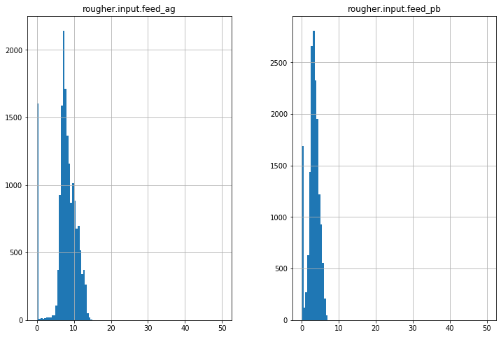

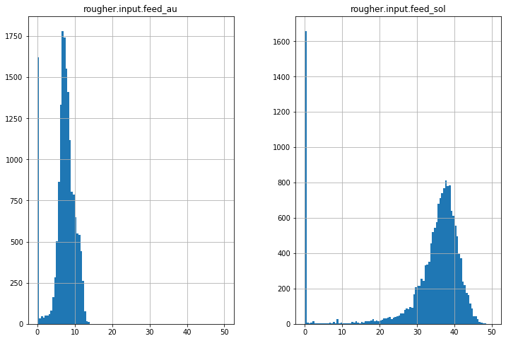

```python
# no.1
data_train[['rougher.input.feed_ag','rougher.input.feed_pb']].hist(bins=100,figsize=(12,8),range=(0,50))
data_train[['rougher.input.feed_sol','rougher.input.feed_au']].hist(bins=100,figsize=(12,8),range=(0,50))
```

```
array([[<matplotlib.axes._subplots.AxesSubplot object at 0x7f63295bc110>,
      dtype=object)
```

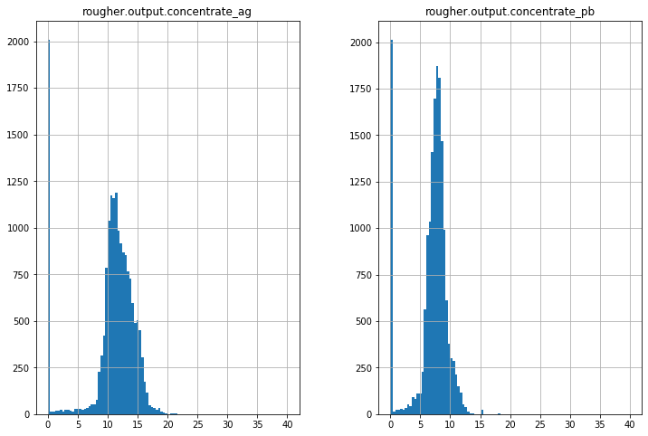

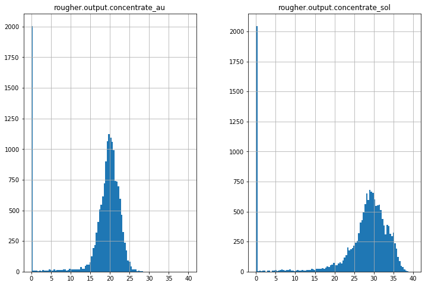

```python
# no.3
data_train[['rougher.output.concentrate_ag','rougher.output.concentrate_pb']].hist(bins=100,figsize=(12,8),range=(0,40))
data_train[['rougher.output.concentrate_sol','rougher.output.concentrate_au']].hist(bins=100,figsize=(12,8),range=(0,40))
```

```
array([[<matplotlib.axes._subplots.AxesSubplot object at 0x7f63290a4510>,
      dtype=object)
```

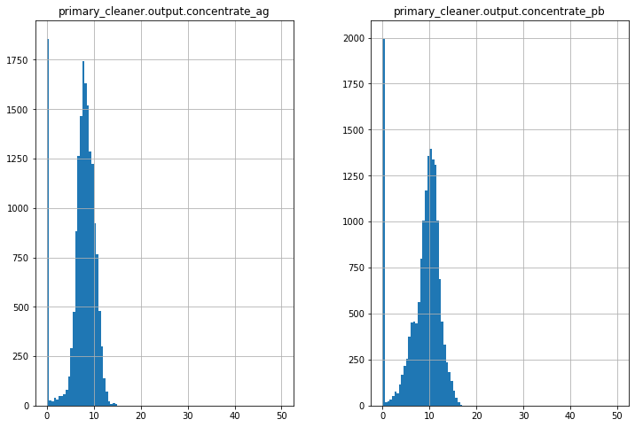

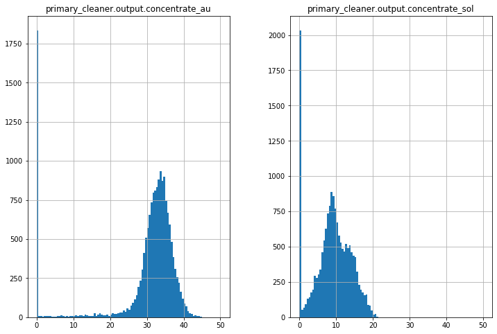

```python
# no.5
data_train[['primary_cleaner.output.concentrate_ag','primary_cleaner.output.concentrate_pb']].hist(bins=100,figsize=(12,8),range=(0,50))
data_train[['primary_cleaner.output.concentrate_sol','primary_cleaner.output.concentrate_au']].hist(bins=100,figsize=(12,8),range=(0,50))
```

```
array([[<matplotlib.axes._subplots.AxesSubplot object at 0x7f6329565b90>,
      dtype=object)
```

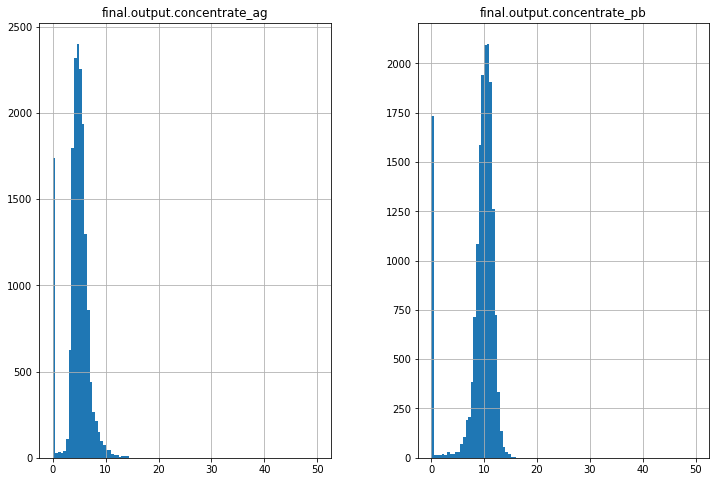

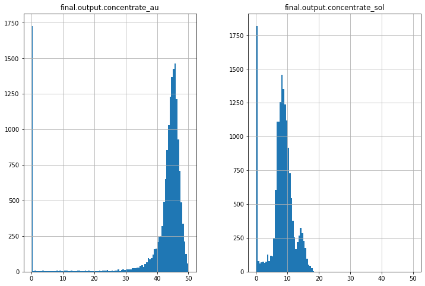

```python
# no.8
data_train[['final.output.concentrate_ag','final.output.concentrate_pb']].hist(bins=100,figsize=(12,8),range=(0,50))
data_train[['final.output.concentrate_sol','final.output.concentrate_au']].hist(bins=100,figsize=(12,8),range=(0,50))
```

```
array([[<matplotlib.axes._subplots.AxesSubplot object at 0x7f63288b2550>,
      dtype=object)
```

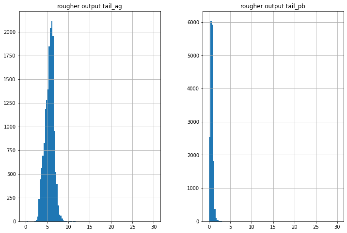

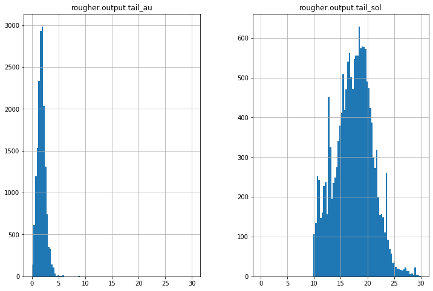

```python
# no.2
data_train[['rougher.output.tail_ag','rougher.output.tail_pb']].hist(bins=100,figsize=(12,8),range=(0,30))
data_train[['rougher.output.tail_sol','rougher.output.tail_au']].hist(bins=100,figsize=(12,8),range=(0,30))
```

```
array([[<matplotlib.axes._subplots.AxesSubplot object at 0x7f632966f850>,
      dtype=object)
```

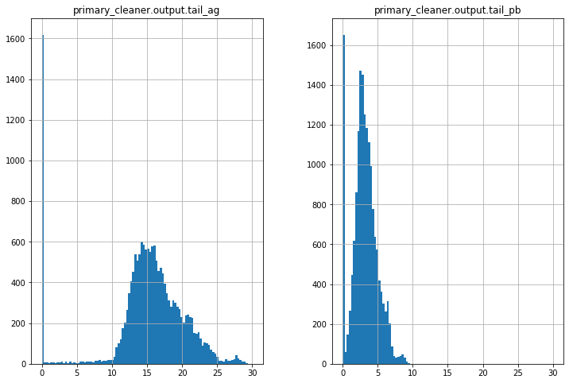

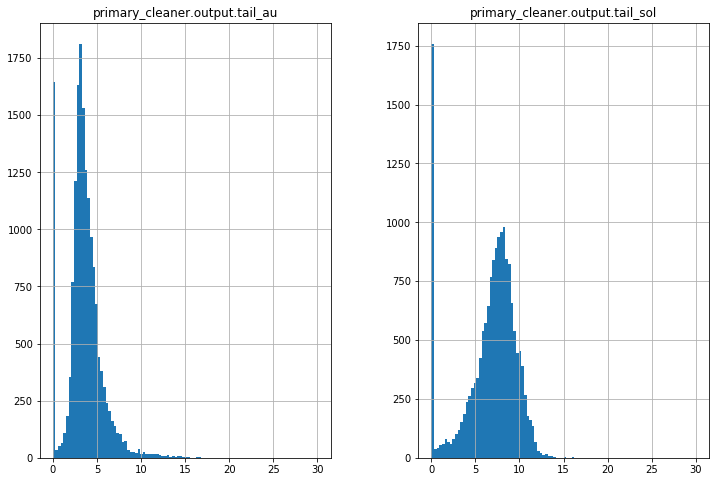

```python
# no.4
data_train[['primary_cleaner.output.tail_ag','primary_cleaner.output.tail_pb']].hist(bins=100,figsize=(12,8),range=(0,30))
data_train[['primary_cleaner.output.tail_sol','primary_cleaner.output.tail_au']].hist(bins=100,figsize=(12,8),range=(0,30))
```

```
array([[<matplotlib.axes._subplots.AxesSubplot object at 0x7f63285166d0>,
      dtype=object)
```

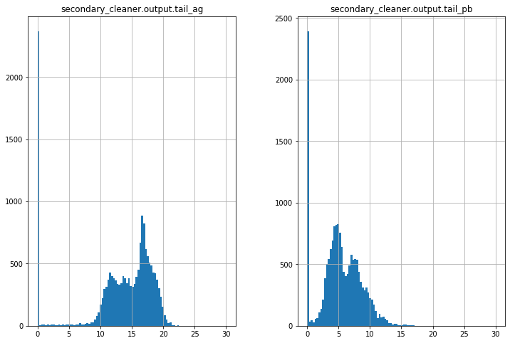

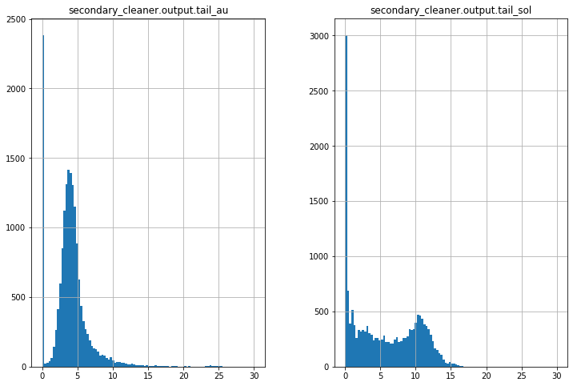

```python
# no.6
data_train[['secondary_cleaner.output.tail_ag','secondary_cleaner.output.tail_pb']].hist(bins=100,figsize=(12,8),range=(0,30))
data_train[['secondary_cleaner.output.tail_sol','secondary_cleaner.output.tail_au']].hist(bins=100,figsize=(12,8),range=(0,30))
```

```
array([[<matplotlib.axes._subplots.AxesSubplot object at 0x7f632875d6d0>,
      dtype=object)
```

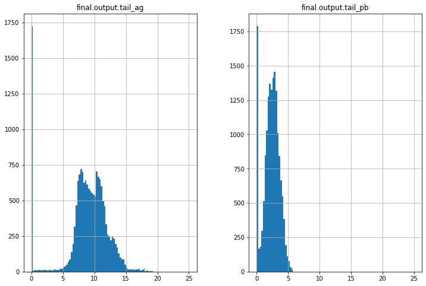

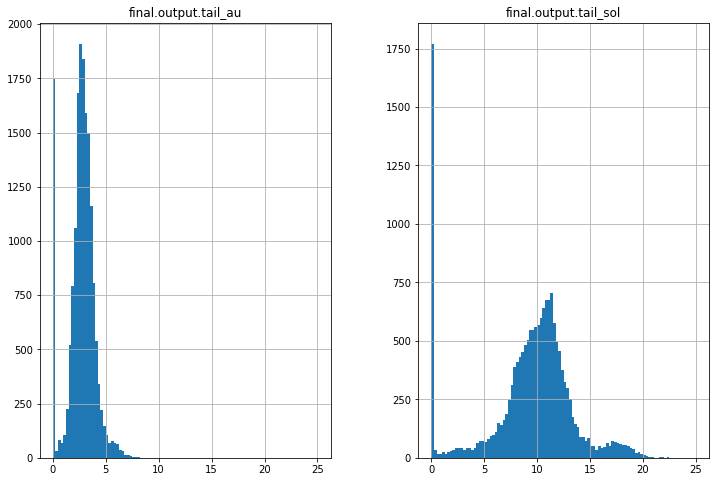

```python
# no.7
data_train[['final.output.tail_ag','final.output.tail_pb']].hist(bins=100,figsize=(12,8),range=(0,25))
data_train[['final.output.tail_sol','final.output.tail_au']].hist(bins=100,figsize=(12,8),range=(0,25))
```

'rougher.input.feed_au', 'rougher.input.feed_ag', 'rougher.input.feed_pb', 'rougher.input.feed_sol'

rougher.output.concentrate*... features and for final.output.concentrate*... ones

[figure not shown]

where:

C — share of gold in the concentrate after flotation/purification

F — share of gold in the feed/concentrate before flotation/purification

T — share of gold in the rougher tails after flotation/purification

To predict the coefficient, you need to find the share of gold in the concentrate and the tails. Note that both final and rougher concentrates matter.

```python
def recovery_calculation (row):
    c = row['rougher.output.concentrate_au']
    f = row['rougher.input.feed_au']
    t = row['rougher.output.tail_au']
    up  = c*(f-t)
    down = f*(c-t)

    if up <=0.0:
        up = 0.0

    if down<=0.0:
        down = 0.0001

    total = (up/down)*100

    if total>100.0:
        total = 100.0

    return total
```

```
count    16860.000000
mean        80.327761
std         18.612822
min          0.000000
25%         78.991703
50%         84.844438
75%         89.825076
max        100.000000
Name: rougher.output.recovery, dtype: float64
```

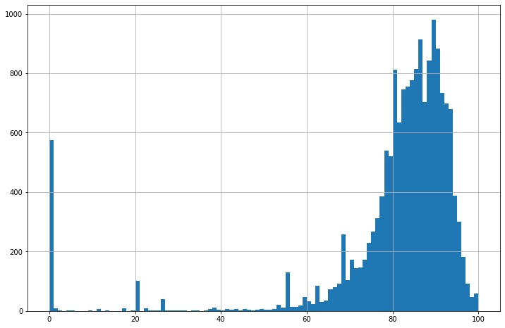

```python
print(data_train['rougher.output.recovery'].describe())
data_train['rougher.output.recovery'].hist(bins=100, figsize=(12,8))
```

```python
data_train['rougher.output.recovery1'] = data_train.apply(recovery_calculation,axis=1)
```

```
count    16860.000000
mean        74.338601
std         28.738179
min          0.000000
25%         77.158030
50%         84.304704
75%         89.842459
max        100.000000
Name: rougher.output.recovery1, dtype: float64
```

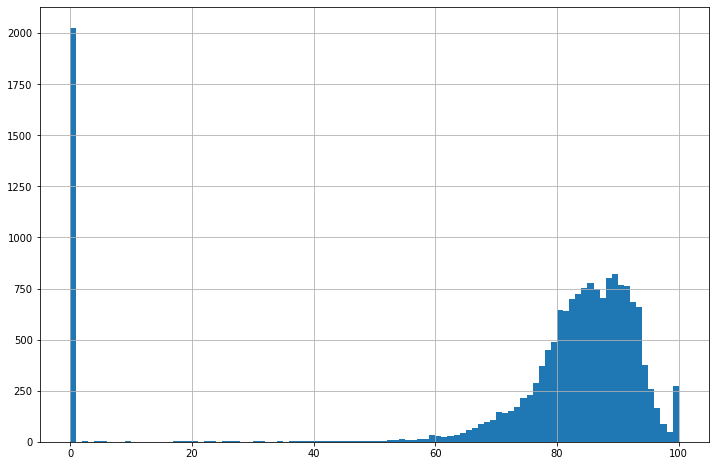

```python
print(data_train['rougher.output.recovery1'].describe())
data_train['rougher.output.recovery1'].hist(bins=100,figsize=(12,8))
```

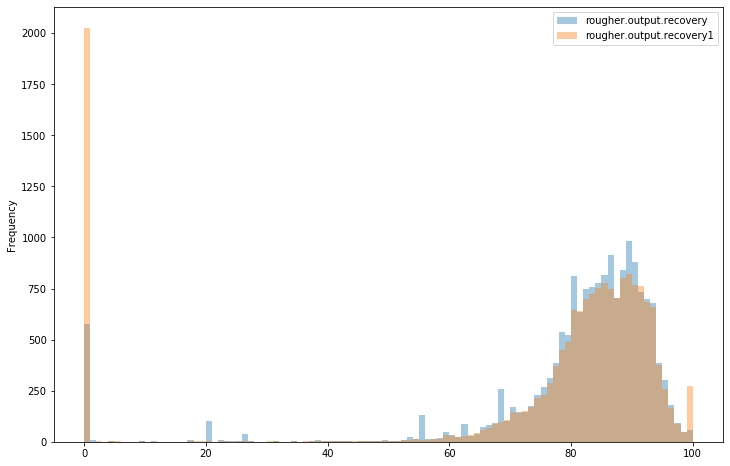

```python
data_train[['rougher.output.recovery','rougher.output.recovery1']].plot.hist(alpha=0.4,bins=100,figsize=(12,8))
```

```python
print('MAE:', mean_absolute_error(data_train['rougher.output.recovery'],data_train['rougher.output.recovery1']))
```

```
MAE: 6.977186941994765
```

## 1.3. Analyzing the features not available in the test set

#### The missing columns are:

final.output.concentrate_ag,final.output.concentrate_pb,final.output.concentrate_sol,final.output.concentrate_au,final.output.recovery,final.output.tail_ag,final.output.tail_sol,final.output.tail_au

primary_cleaner.output.concentrate_ag,primary_cleaner.output.concentrate_pb,primary_cleaner.output.concentrate_sol,primary_cleaner.output.concentrate_au,primary_cleaner.output.tail_ag,primary_cleaner.output.tail_pb,primary_cleaner.output.tail_sol,primary_cleaner.output.tail_au

rougher.calculation.sulfate_to_au_concentrate,rougher.calculation.floatbank10_sulfate_to_au_feed,rougher.calculation.floatbank11_sulfate_to_au_feed,rougher.calculation.au_pb_ratio

rougher.output.concentrate_ag,rougher.output.concentrate_pb,rougher.output.concentrate_sol,rougher.output.concentrate_au,rougher.output.recovery,rougher.output.tail_ag,rougher.output.tail_pb,rougher.output.tail_sol,rougher.output.tail_au

secondary_cleaner.output.tail_ag,secondary_cleaner.output.tail_pb,secondary_cleaner.output.tail_so,secondary_cleaner.output.tail_au.

We can see that all the tail, concentrate and final output is missing. Thus, we have only the input, but the hole process is missing.

## 1.4. Performing data preprocessing.

We will need to deal with null, different columns, invalid numbers. After trying to drop nan values, we lost almost 1/3 of the information. Thus, we are going to fill this nan values with values that are near to them. This step is ok since the only object variable appears in all rows.

The process was done before in order to find the difference in 1.2.

# 2. Analyzing the data

## 2.1. Taking note of how the concentrations of metals change

On metals {Au, Ag, Pb}, how the concentrations change depending on the purification stage.

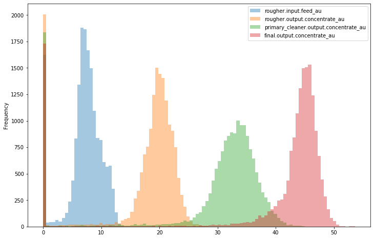

```python
# Au
data_train[['rougher.input.feed_au','rougher.output.concentrate_au','primary_cleaner.output.concentrate_au','final.output.concentrate_au']].plot.hist(alpha=0.4,bins=100,figsize=(12,8))
```

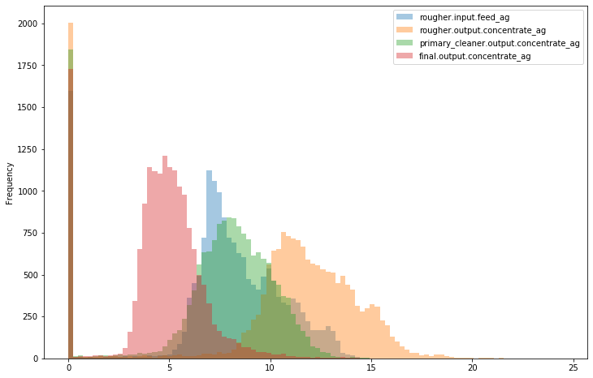

```python
# Ag
data_train[['rougher.input.feed_ag','rougher.output.concentrate_ag','primary_cleaner.output.concentrate_ag','final.output.concentrate_ag']].plot.hist(alpha=0.4,bins=100,figsize=(12,8))
```

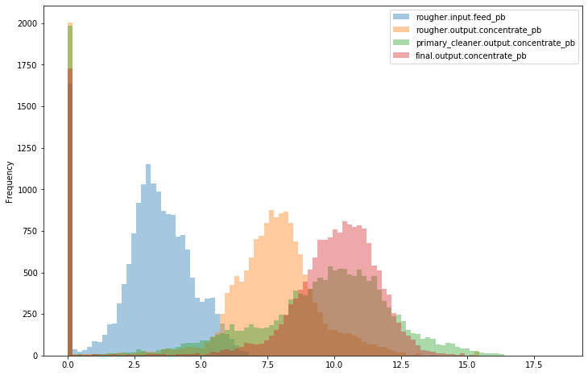

```python
# Pb
data_train[['rougher.input.feed_pb','rougher.output.concentrate_pb','primary_cleaner.output.concentrate_pb','final.output.concentrate_pb']].plot.hist(alpha=0.4,bins=100,figsize=(12,8))
```

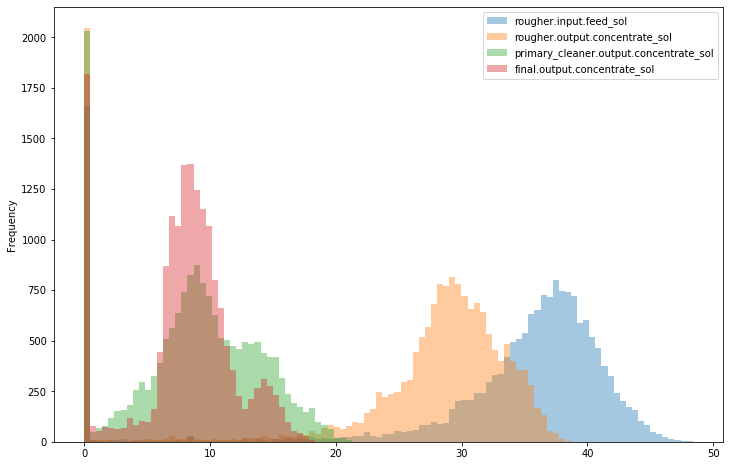

```python
# Sol
data_train[['rougher.input.feed_sol','rougher.output.concentrate_sol','primary_cleaner.output.concentrate_sol','final.output.concentrate_sol']].plot.hist(alpha=0.4,bins=100,figsize=(12,8))
```

There are some metals that get more concentrated with the proceeding of the process like Au and Pb, but, in contrast, Ag and Sb metals loose from there concentration during the process.

Focusing on gold (Au), in each step the metal gets more concentrated by more than 12%, starting with an average of 8, and ending with an average of 46.

## 2.2. Comparing the feed particle size distributions:

In the training set and in the test set.

If the distributions vary significantly, the model evaluation will be incorrect.

```
No handles with labels found to put in legend.
```

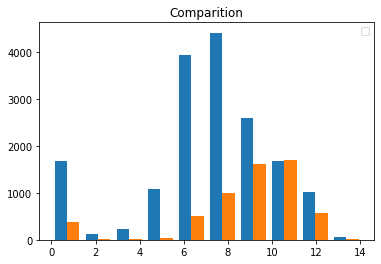

```python
a = data_train['rougher.input.feed_au']
b = data_test['rougher.input.feed_au']

fig, ax = plt.subplots()
ax.hist([a, b])
ax.set_title("Comparition")
ax.legend()
```

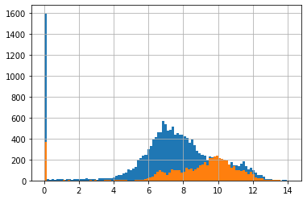

```python
data_train['rougher.input.feed_au'].hist(bins=100)
data_test['rougher.input.feed_au'].hist(bins=100)
```

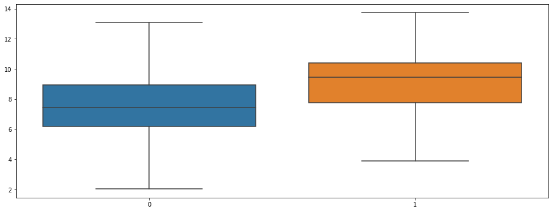

```python
plt.figure(figsize=(16,6))
ax = sns.boxplot(data=(a,b), showfliers=False)
```

```python
print(a.describe())
print(b.describe())
```

```
count    16860.000000
mean         7.144279
std          3.026064
min          0.000000
25%          6.186757
50%          7.429346
75%          8.954083
max         14.093363
Name: rougher.input.feed_au, dtype: float64
count    5856.000000
mean        8.702056
std         2.805083
min         0.000000
25%         7.765897
50%         9.455566
75%        10.383540
max        13.731330
Name: rougher.input.feed_au, dtype: float64
```

We can see that there is a different of almost 2% between train and test, where test is bigger. Both have enaugh observations in order to say that there mean is okay, not sure if they would pass the t-test. We still can say all numbers are around the same percentage for quantile.

```python
def ttest_general(a,b):
    alpha = .05       # critical statistical significance level

    results = st.ttest_ind(a,b,equal_var=False)
    print('p-value: {:.10f}'.format(results.pvalue))

    if (results.pvalue<alpha):
        print("We reject the null hypothesis")
    else:
        print("We can't reject the null hypothesis")

ttest_general(a,b)
```

```
p-value: 0.0000000000
We reject the null hypothesis
```

## 2.3. Considering the total concentrations of all substances at different stages:

{raw feed, rougher concentrate, and final concentrate}.

Noticing abnormal values in the total distribution. Removing such values if needed from both samples. Describing the findings and eliminatinf anomalies.

```
array([[<matplotlib.axes._subplots.AxesSubplot object at 0x7f632365a990>,
      dtype=object)
```

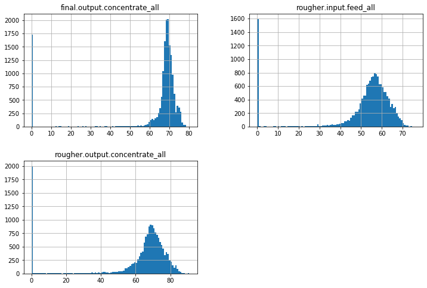

```python
data_train['rougher.input.feed_all'] = data_train['rougher.input.feed_ag'] + data_train['rougher.input.feed_au'] + data_train['rougher.input.feed_pb'] + data_train['rougher.input.feed_sol']
data_train['rougher.output.concentrate_all'] = data_train['rougher.output.concentrate_ag'] + data_train['rougher.output.concentrate_au'] + data_train['rougher.output.concentrate_pb'] + data_train['rougher.output.concentrate_sol']
data_train['final.output.concentrate_all'] = data_train['final.output.concentrate_ag'] + data_train['final.output.concentrate_au'] + data_train['final.output.concentrate_pb'] + data_train['final.output.concentrate_sol']
data_train[['rougher.input.feed_all','rougher.output.concentrate_all','final.output.concentrate_all']].hist(bins=100,figsize=(12,8))
```

The final process has the best percentage of success, with 70%. Also first stage has good percentage of 70%. On the other hand, the input has the lower insuccesfull process with only 1600 observations with 0 percentage of concentration, meaning that something is wrong on the metal or the process.

# 3. Building the model

## 3.1. A function to calculate the final sMAPE value

To solve the problem, we will need a new metric. It is called sMAPE, symmetric Mean Absolute Percentage Error. It is similar to MAE, but is expressed in relative values instead of absolute ones. Why is it symmetrical? It equally takes into account the scale of both the target and the prediction.

[figure not shown]

```python
def smape (target,prediction):
    up = abs(target-prediction)
    down = (abs(target)+abs(prediction))/2
    fraction = up/down
    sigma = fraction.sum()
    total = (sigma/len(target))*100
    return total
```

```python
def final_smape (ro_t,ro_p,fi_t,fi_p):
    ro = 0.25*smape(ro_t,ro_p)
    fi = 0.75*smape(fi_t,fi_p)
    total = ro + fi
    return total
```

```python
def split_prediction (predicted):
    roughe = []
    final = []
    for i in range(len(predicted)):
        a = predicted[i][0]
        b = predicted[i][1]
        roughe.append(a)
        final.append(b)
    return roughe, final
```

## 3.2. Training different models.

Evaluating them using cross-validation.

The best model is beeing picked and tested using the test sample.

Providing findings.

```python
# splitting the data
dates_of_test = data_test['date']
target = data_train[['rougher.output.recovery', 'final.output.recovery']]
features = data_train.drop(columns=['date','rougher.output.recovery', 'final.output.recovery'], axis=1)
features_test = data_test.drop(columns=['date'], axis=1)
target_test = data_full.loc[data_full['date'].isin(dates_of_test)]
target_test = target_test.reset_index(drop=True)
target_test_rougher = target_test['rougher.output.recovery']
target_test_final = target_test['final.output.recovery']
```

```python
# removing uncommon columns from the train features
cols = features.columns.intersection(features_test.columns)
features_1 = features[cols]
```

```python
def cross_val_score_linear_regression (features, target):
    scores = []
    sample_size = int(len(features)/3)
    for i in range(0, len(features), sample_size):
        valid_indexes = features.iloc[i:i+sample_size].index
        train_indexes = features[~(features.index.isin(valid_indexes))].index

        features_train = features.iloc[train_indexes]
        features_valid = features.iloc[valid_indexes]
        target_train = target.iloc[train_indexes]
        target_valid = target.iloc[valid_indexes].reset_index()

        model = LinearRegression()
        model = model.fit(features_train, target_train)
        predicted_valid = model.predict(features_valid)
        roughe, final = split_prediction(predicted_valid)
        smape = final_smape(target_valid['rougher.output.recovery'],pd.Series(roughe),target_valid['final.output.recovery'],pd.Series(final))
        scores.append(smape)
    return scores
```

```python
scores = cross_val_score_linear_regression (features_1, target)
final_score = pd.Series(scores).mean()
print('LinearRegression Average model sMAPE score:', final_score)
```

```
LinearRegression Average model sMAPE score: 18.324147447359934
```

```python
def cross_val_score_randomForest_regressor (features, target,estimators):
    scores = []
    sample_size = int(len(features)/3)
    for i in range(0, len(features), sample_size):
        valid_indexes = features.iloc[i:i+sample_size].index
        train_indexes = features[~(features.index.isin(valid_indexes))].index

        features_train = features.iloc[train_indexes]
        features_valid = features.iloc[valid_indexes]
        target_train = target.iloc[train_indexes]
        target_valid = target.iloc[valid_indexes].reset_index()

        model = RandomForestRegressor(n_estimators=estimators, random_state=12345)
        model = model.fit(features_train, target_train)
        predicted_valid = model.predict(features_valid)
        roughe, final = split_prediction(predicted_valid)
        smape = final_smape(target_valid['rougher.output.recovery'],pd.Series(roughe),target_valid['final.output.recovery'],pd.Series(final))
        scores.append(smape)
    return scores
```

```python
for estimators in range(10,101,10):
    scores = cross_val_score_randomForest_regressor (features_1, target,estimators)
    final_score = pd.Series(scores).mean()
    print("Estimators =", estimators, ": ", end='')
    print('RandomForestRegressor Average model sMAPE score:', final_score)
    print('----------------------------------------------')
```

[output not shown]

### DecisionTreeRegressor

```python
def cross_val_score_decisionTree_regressor (features, target,depth):
    scores = []
    sample_size = int(len(features)/3)
    for i in range(0, len(features), sample_size):
        valid_indexes = features.iloc[i:i+sample_size].index
        train_indexes = features[~(features.index.isin(valid_indexes))].index

        features_train = features.iloc[train_indexes]
        features_valid = features.iloc[valid_indexes]
        target_train = target.iloc[train_indexes]
        target_valid = target.iloc[valid_indexes].reset_index()

        model = DecisionTreeRegressor(max_depth=depth,random_state=12345)
        model = model.fit(features_train, target_train)
        predicted_valid = model.predict(features_valid)
        roughe, final = split_prediction(predicted_valid)
        smape = final_smape(target_valid['rougher.output.recovery'],pd.Series(roughe),target_valid['final.output.recovery'],pd.Series(final))
        scores.append(smape)
    return scores
```

```python
for depth in range(1,10):
    scores = cross_val_score_decisionTree_regressor (features_1, target,depth)
    final_score = pd.Series(scores).mean()
    print("Depth =", depth, ": ", end='')
    print('DecisionTreeRegressor Average model sMAPE score:', final_score)
    print('----------------------------------------------')
```

```
Depth = 1 : DecisionTreeRegressor Average model sMAPE score: 15.870867225369906
----------------------------------------------
Depth = 2 : DecisionTreeRegressor Average model sMAPE score: 15.694765615955795
----------------------------------------------
Depth = 3 : DecisionTreeRegressor Average model sMAPE score: 16.500512334071058
----------------------------------------------
Depth = 4 : DecisionTreeRegressor Average model sMAPE score: 17.855670157858256
----------------------------------------------
Depth = 5 : DecisionTreeRegressor Average model sMAPE score: 19.10357998925183
----------------------------------------------
Depth = 6 : DecisionTreeRegressor Average model sMAPE score: 18.853874219507134
----------------------------------------------
Depth = 7 : DecisionTreeRegressor Average model sMAPE score: 18.891381929308768
----------------------------------------------
Depth = 8 : DecisionTreeRegressor Average model sMAPE score: 23.594757542303938
----------------------------------------------
Depth = 9 : DecisionTreeRegressor Average model sMAPE score: 24.1912542906211
----------------------------------------------
```

Best result for DecisionTreeRegressor is for a tree with depth of 2, with a sMAPE score of 15.6947656.